# stat_part1_

### Стандартное отклонение

Оценка стандартного отклонения на основании несмещённой оценки дисперсии

${\displaystyle S_{0}={\sqrt {{\frac {n}{n-1}}S^{2}}}={\sqrt {{\frac {1}{n-1}}\sum _{i=1}^{n}\left(x_{i}-{\bar {x}}\right)^{2}}}.}$

```python
np.std(stats.norm(0, 1).rvs(size=10))
```

```
0.5666020902721973
```

```python
print(np.var(stats.norm(0, 3).rvs(size=1000, random_state=17)))
print(np.std(stats.norm(0, 3).rvs(size=1000, random_state=17)))
```

```
9.334999756362558
3.055323183619461
```

### Медиана

Если все элементы выборки различны, то **медиана** — это такое число выборки, что ровно половина из элементов выборки больше него, а другая половина меньше него. В более общем случае медиану можно найти, упорядочив элементы выборки по возрастанию или убыванию и взяв средний элемент. Например, выборка {11, 9, 3, 5, 5} после упорядочивания превращается в {3, 5, 5, 9, 11} и её медианой является число 5. Если в выборке чётное число элементов, медиана может быть не определена однозначно: для числовых данных чаще всего используют полусумму двух соседних значений (то есть медиану набора {1, 3, 5, 7} принимают равной 4)

Если распределение непрерывно, то медиана является одним из решений уравнения

$F(x)=0.5$

```python
print(np.mean(stats.norm(0, 1).rvs(size=10000, random_state = 17)))
print(np.median(stats.norm(0, 1).rvs(size=10000, random_state = 17)))
```

```
-0.006796445530111585
-0.010455421629235202
```

```python
lst = [0, 1, 2, 3, 2, 1, 2, 1, 0]

print(np.mean(lst), np.median(lst))

print(stats.mode(lst))
```

```
1.3333333333333333 1.0
ModeResult(mode=1, count=3)
```

### Мода

Мо́да — значение во множестве наблюдений, которое встречается наиболее часто.

```python
stats.norm(0, 1).rvs(size=10000)
```

```
array([ 0.72276784, -0.76497342, -0.6090986 , ...,  1.23008685,
       -0.14314351,  1.29464421])
```

```python
func_round = lambda x: round(x, 5)
norm_distr = stats.norm(0, 1).rvs(size=1000000, random_state=17)
```

```python
stats.mode(list(map(func_round,norm_distr))).mode
```

```
-0.25285
```

### Квантили

Это значение, которое заданная случайная величина не превышает с фиксированной вероятностью. Если вероятность задана в процентах, то квантиль называется процентилем или перцентилем.

Например, фраза «90-й процентиль массы тела у новорожденных мальчиков составляет 4 кг» означает, что 90 % мальчиков рождаются с весом меньше, либо равным 4 кг, а 10 % мальчиков рождаются с весом больше 4 кг.

Для непрерывных распределений справедливо следующее равенство:

$${\mathbb {P}}\left(x_{{{\frac {1-\alpha }{2}}}}\leqslant X\leqslant x_{{{\frac {1+\alpha }{2}}}}\right)=\alpha$$

```python
lst = [1, 2, 3, 4, 5, 6, 7, 8, 9, 10]
```

```python
np.quantile(lst, 0.25, interpolation = 'nearest')
```

```
3
```

```python
np.quantile([1, 2, 3, 4, 5], 0.5)
```

```
3.0
```

#### 0.5 Квантиль == Медиана!

```python
np.quantile(lst, 0.5)
```

```
5.5
```

```python
np.median(lst)
```

```
5.5
```

```python
import math
def quantile(list_,a):
    k=(1/a)
    h=math.floor(len(list_)/k)
    if len(list_)%2!=0:
        q=list_[h]
    if len(list_)%2==0:
        q=(list_[h-1]+list_[h])/2
    return q
```

```python
quantile([1, 2, 3, 4, 5], 0.25)
```

```
2
```

```python
np.quantile([[1, 2, 3, 4, 5]], 0.25, interpolation='nearest')
```

```
2
```

### Перцентиль (или процентиль)

p-м проценти́лем называют квантиль уровня ${\displaystyle \alpha =p/100}$. Соответственно, медиана является 50-м процентилем, а первый и третий квартиль — 25-м и 75-м процентилями соответственно.

```python
lst = [1, 2, 3, 4, 5, 6, 7, 8, 9, 10]

np.percentile(lst, 25, interpolation='nearest')
```

```
3
```

```python
np.percentile(lst, 25.6,interpolation='nearest')
```

```
3
```

### Ковариация

https://habr.com/ru/post/304214/

В случае с многомерной случайной величиной (случайным вектором) положение центра все так же будет являться мат. ожиданиями ее проекций на оси. А вот для описания ее формы уже недостаточно толькое ее дисперсий по осям. Посмотрите на эти графики, у всех трех случайных величин одинаковые мат.ожидания и дисперсии, а их проекции на оси в целом окажутся одинаковы!

[figure not shown]

Ковариа́ция (корреляционный момент, ковариационный момент) — в теории вероятностей и математической статистике мера линейной зависимости двух случайных величин.

Пусть $X,Y$ — две случайные величины, определённые на одном и том же вероятностном пространстве. Тогда их ковариация определяется следующим образом:

$${\mathrm {cov}}(X,Y)={\mathbb {M}}\left[(X-{\mathbb {M}}X)(Y-{\mathbb {M}}Y)\right]$$,

где ${\mathbb {M}}$— математическое ожидание (в англоязычной литературе принято обозначение ${\mathbb {E}})$.

```python
stats.norm(0, 1).rvs(size=10).reshape(1, -1)
```

```
array([[ 2.49886037, -0.69849279, -0.29875151,  0.6583115 , -1.9120001 ,
         0.53676175,  2.73467094,  1.10309081, -0.7482813 , -1.30772527]])
```

```python
mtx = np.concatenate((stats.norm(0, 1).rvs(size=10).reshape(1, -1), stats.norm(0, 1).rvs(size=10).reshape(1, -1)))
print(mtx)

print(np.cov(mtx))
```

```
[[ 1.70885897  0.63804639 -1.82661079 -0.87974901 -0.79318552  1.50804545
   1.34297324 -0.16702669 -0.3917856   0.44385712]
 [-0.44371336 -0.67362545  0.17407663 -0.01471943 -1.46244754 -0.33345651
  -1.22071439 -0.87514649  1.02299086  0.43519514]]
[[ 1.36359655 -0.22219544]
 [-0.22219544  0.58586444]]
```

```python
mtx = np.array([[1, 2, 3, 4], [4, 3, 2, 1]])
print(mtx)

print(np.cov(mtx))
print(np.var(mtx[1]))
```

```
[[1 2 3 4]
 [4 3 2 1]]
[[ 1.66666667 -1.66666667]
 [-1.66666667  1.66666667]]
1.25
```

## Корреляция

**Корреля́ция** (от лат. correlatio «соотношение, взаимосвязь»), или корреляционная зависимость, — статистическая взаимосвязь двух или более случайных величин (либо величин, которые можно с некоторой допустимой степенью точности считать таковыми). При этом изменения значений одной или нескольких из этих величин сопутствуют систематическому изменению значений другой или других величин

Ковариация имеет размерность, равную произведению размерности случайных величин, то есть величина ковариации зависит от единиц измерения независимых величин. Данная особенность ковариации затрудняет её использование в целях корреляционного анализа

**Линейный коэффициент корреляции**

[figure not shown]

где ${\overline {X}}={\frac {1}{n}}\sum _{t=1}^{n}X_{t}$, ${\overline {Y}}={\frac {1}{n}}\sum _{t=1}^{n}Y_{t}$ — среднее значение выборок.

```python
stats.pearsonr(stats.norm(0, 1).rvs(size=1000), stats.norm(0, 1).rvs(size=1000))[0]
```

```
-0.02293662811311594
```

```python
mtx = np.array([[1, 2, 3, 4], [4, 3, 2, 1]])
stats.pearsonr(mtx[0], mtx[1])[0]
```

```
-1.0
```

https://tylervigen.com/spurious-correlations

```python
import pandas as pd
```

```python
df_churn = pd.read_csv('telecom_churn.csv')
```

```python
df_churn.head()
```

|  | State | Account length | Area code | International plan | Voice mail plan | Number vmail messages | Total day minutes | Total day calls | Total day charge | Total eve minutes | Total eve calls | Total eve charge | Total night minutes | Total night calls | Total night charge | Total intl minutes | Total intl calls | Total intl charge | Customer service calls | Churn |
| --- | --- | --- | --- | --- | --- | --- | --- | --- | --- | --- | --- | --- | --- | --- | --- | --- | --- | --- | --- | --- |
| 0 | KS | 128 | 415 | No | Yes | 25 | 265.1 | 110 | 45.07 | 197.4 | 99 | 16.78 | 244.7 | 91 | 11.01 | 10.0 | 3 | 2.70 | 1 | False |
| 1 | OH | 107 | 415 | No | Yes | 26 | 161.6 | 123 | 27.47 | 195.5 | 103 | 16.62 | 254.4 | 103 | 11.45 | 13.7 | 3 | 3.70 | 1 | False |
| 2 | NJ | 137 | 415 | No | No | 0 | 243.4 | 114 | 41.38 | 121.2 | 110 | 10.30 | 162.6 | 104 | 7.32 | 12.2 | 5 | 3.29 | 0 | False |
| 3 | OH | 84 | 408 | Yes | No | 0 | 299.4 | 71 | 50.90 | 61.9 | 88 | 5.26 | 196.9 | 89 | 8.86 | 6.6 | 7 | 1.78 | 2 | False |
| 4 | OK | 75 | 415 | Yes | No | 0 | 166.7 | 113 | 28.34 | 148.3 | 122 | 12.61 | 186.9 | 121 | 8.41 | 10.1 | 3 | 2.73 | 3 | False |

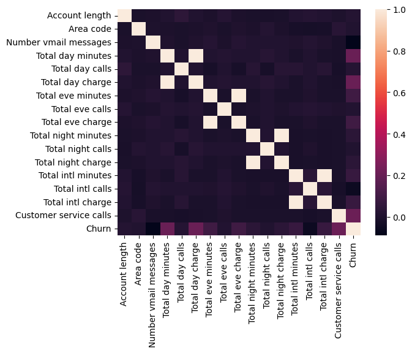

```python
sns.heatmap(df_churn.corr());
```

### Отсутствие корреляции

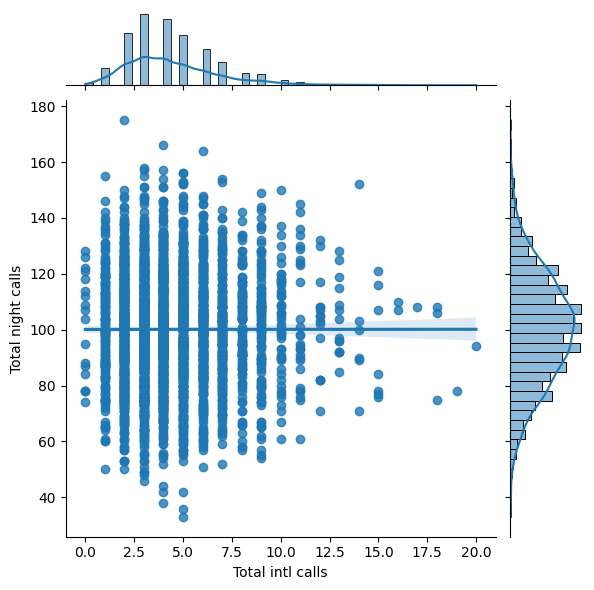

```python
sns.jointplot(data=df_churn, x='Total intl calls', y='Total night calls', kind='reg')
```

### Тут максимальная корреляция

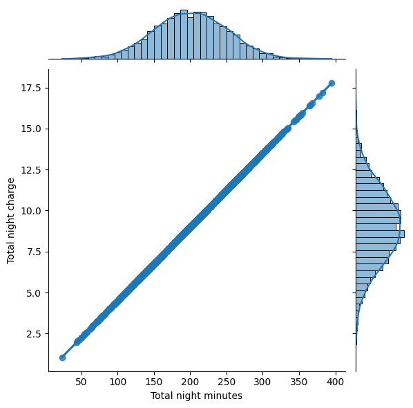

```python
sns.jointplot(data=df_churn, x='Total night minutes', y='Total night charge', kind='reg')
```

```python
df_churn['Churn'] = df_churn['Churn'].astype(int)
```

```python
df_churn['total minutes'] = df_churn[['Total eve minutes','Total night minutes','Total day minutes']].sum(axis = 1)
```

```python
df_churn.columns
```

```
Index(['State', 'Account length', 'Area code', 'International plan',
       'Voice mail plan', 'Number vmail messages', 'Total day minutes',
       'Total day calls', 'Total day charge', 'Total eve minutes',
       'Total eve calls', 'Total eve charge', 'Total night minutes',
       'Total night calls', 'Total night charge', 'Total intl minutes',
       'Total intl calls', 'Total intl charge', 'Customer service calls',
       'Churn', 'total minutes'],
      dtype='object')
```

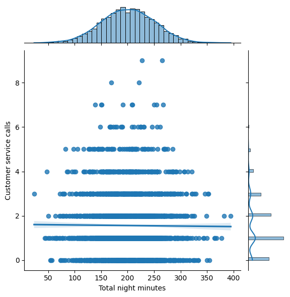

```python
sns.jointplot(data=df_churn,x='Total night minutes',
              y='Customer service calls', kind='reg')
```

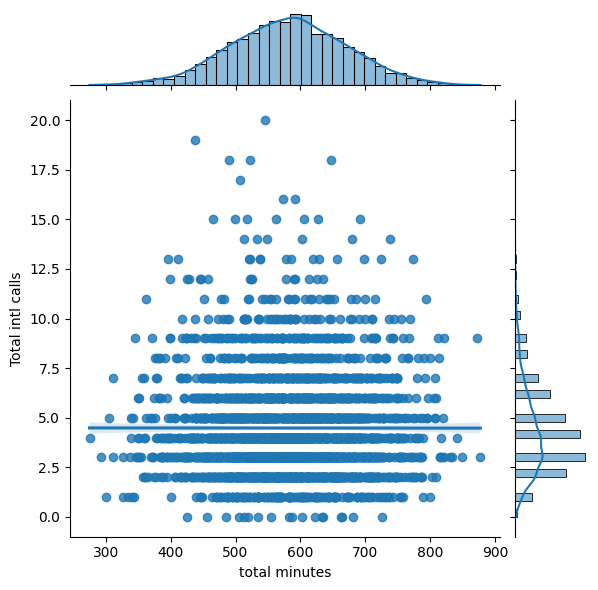

```python
sns.jointplot(data=df_churn, x='total minutes',
              y='Total intl calls', kind='reg')
```

```python
df_churn.columns
```

```
Index(['State', 'Account length', 'Area code', 'International plan',
       'Voice mail plan', 'Number vmail messages', 'Total day minutes',
       'Total day calls', 'Total day charge', 'Total eve minutes',
       'Total eve calls', 'Total eve charge', 'Total night minutes',
       'Total night calls', 'Total night charge', 'Total intl minutes',
       'Total intl calls', 'Total intl charge', 'Customer service calls',
       'Churn', 'total minutes'],
      dtype='object')
```

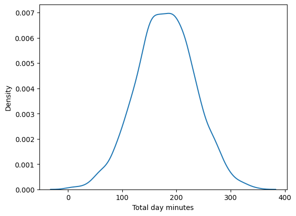

```python
sns.kdeplot(df_churn['Total day minutes']);
```

```python
df_churn['Churn'].value_counts()
```

```
0    2850
1     483
Name: Churn, dtype: int64
```

```python
sns.pairplot(df_churn)
```

```
Output hidden; open in https://colab.research.google.com to view.
```